**Submitted by**: M. Hasnain Naeem (212728) from BSCS-7B, NUST

# Digital Image Processing

## Lab 4 - Transformation Functions and Geometric Transforms from Scratch and using OpenCV

**Objectives:** The objectives of this lab are:

```
- To apply Log transformation on images and visualize results.
- To apply power-law transform to correct gamma in images.
- To apply various geometric transformations (like translation, rotation, scaling, sheering and affine) on images and see their effects.
```

```python
import os
import math
import numpy as np
import cv2

import matplotlib.pyplot as plt
%matplotlib inline
```

```python
def get_gray_image(name, img_dir="files/imgs"):
    # open file and convert to grey scale
    filename = os.path.join(os.curdir, img_dir, name)

    img = cv2.imread(filename)
    gray_img = cv2.cvtColor(img, cv2.COLOR_BGR2GRAY)

    return gray_img
```

```python
def get_intensity_counts(gray_img):
    intensity_count = np.zeros(256, "int")
    for i, row in enumerate(gray_img):
        for j, intensity_val in enumerate(row):
            intensity_count[intensity_val] += 1
    return intensity_count
```

```python
def plot_intensity_hists(bins, intensity_counts, saving_dir, filename):
    save_loc = os.path.join(saving_dir, filename+"_intensity_histogram"+".jpg")

    plt.bar(bins, intensity_counts, color='#0504aa')

    plt.grid(axis='y', alpha=0.75)
    plt.xlabel('Intensity Value')
    plt.ylabel('Intensity Value Count')
    plt.title("Intensity Value Histogram for "+filename)

    plt.savefig(save_loc, bbox_inches="tight", dpi=100)
    plt.show()
```

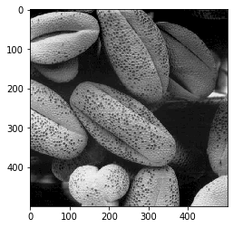

```python
# get all the filenames in the directory
imgs_dir = os.path.join(os.curdir, "files", "imgs")
img_names = os.listdir("files/imgs")

# get filename --> gray_image mapping for future usage
gray_imgs = dict()
for img_name in img_names:
    gray_img = get_gray_image(img_name)
    gray_imgs[img_name] = gray_img
    plt.imshow(gray_img, cmap="gray")
    plt.show()
```

### Task 1

1. Use python notebook and opencv’s imread function and load an image (e.g. dark.tif)
2. Visualize histogram by plotting the histogram.
3. Apply log transform on image and visualize the output histogram.
4. Try to experiment by changing the scaling constant c
5. Summarize your findings by providing a figure containing 4 plots (input image, histogram of input image, output image and histogram of output image)

#### Log Transformation

```python
def log_transform(img, args):
    log_transformed_img = np.zeros(img.shape, "int")

    # calculate scaling constant
    c = (255)/(math.log(1+np.max(img)))

    # transform all intensities
    for i, row in enumerate(img):
        for j, val in enumerate(row):
            # transform current intensity value
            log_transformed_img[i, j] = c * math.log(1+val)

    return log_transformed_img
```

```python
def transform_and_hists(img_name, gray_img, trans_func, saving_dir, **kwargs):
    print(img_name)
    print("************")

    print("Original Image:")
    plt.imshow(gray_img, cmap="gray")
    plt.show()

    bins = [i for i in range(256)]
    # plot intensity histogram
    intensity_count = get_intensity_counts(gray_img)
    plot_intensity_hists(bins, intensity_count, saving_dir, img_name)

    # transformation
    transformed_img = trans_func(gray_img, kwargs)

    # new file name & location
    new_path = os.path.join(saving_dir, "transformed", img_name+"_transformed.jpg")
    plt.imsave(new_path, transformed_img, cmap="gray")

    print("Transformed Image:")
    plt.imshow(transformed_img, cmap="gray")
    plt.show()

    # plot histogram of transformed image
    intensity_count = get_intensity_counts(transformed_img)
    plot_intensity_hists(bins, intensity_count, saving_dir, img_name+"_"+trans_func.__name__+"_transformed.jpg")
```

#### Draw Histogram of Image, Transform, Draw Histogram of Transformed Image

```
aerial.tif
************
Original Image:
```

```
Transformed Image:
```

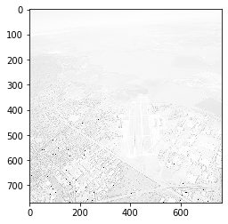

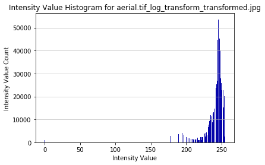

```
dark.tif
************
Original Image:
```

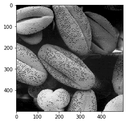

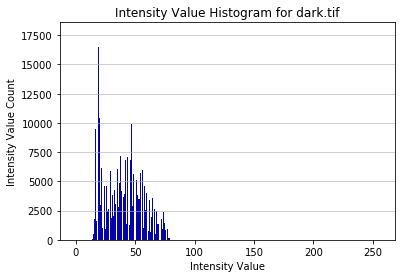

```
Transformed Image:
```

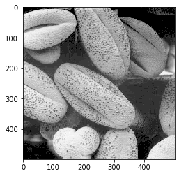

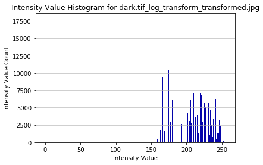

```
messi5.jpg
************
Original Image:
```

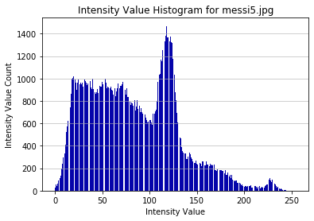

```
Transformed Image:
```

[figure not shown]

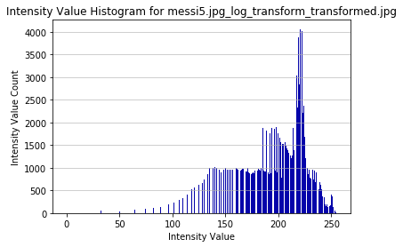

```python
task1_dir = os.path.join(os.curdir, "files", "task1")
task1_transformed_dir = os.path.join(task1_dir, "transformed")

# create directories doesn't exist
if not os.path.exists(task1_dir):
    os.makedirs(task1_dir)
if not os.path.exists(task1_transformed_dir):
    os.makedirs(task1_transformed_dir)

# perform operations on all the images
for img_name, gray_img in gray_imgs.items():
    transform_and_hists(img_name, gray_img, log_transform, task1_dir)
```

### Task 2

- Read “aerial.tif” image in python notebook and store that in “img” variable. - Read the documentation of Interact from ipywidgets and create a slider named gamma.
- By using the value of gamma, apply a power-law transform on image and figure out which value of gamma can result in a contrast enhanced output.
- **HINT:** since you have to apply this transformation to each pixel, nested for loops including the power-law operation should do the trick.
- Summarize your findings by providing a figure containing 4 plots (input image, histogram of input image, output image and histogram of output image)

#### Functions for Power Law Transformation & Histogram Generation

```python
def power_law(img, args):
    gamma_val = args["gamma_val"]
    c = args["c_val"]

    gamma_transformed_img = np.zeros(img.shape, "int")

    # transform all intensities
    for i, row in enumerate(img):
        for j, val in enumerate(row):
            # transform current intensity value
            gamma_transformed_img[i, j] = int(c * math.pow(val, gamma_val))

    return gamma_transformed_img
```

```python
def power_law_pixel(intensity_val, args):
    gamma_val = args["gamma_val"]
    c = args["c_val"]

    transformed_intensity = int(c * math.pow(intensity_val, gamma_val))

    return transformed_intensity
```

```python
def gen_power_law_table(args):
    # generate gamma table
    gamma_table = dict()
    for i in range(256):
        gamma_table[i] = power_law_pixel(i, args)

    return gamma_table
```

```python
def power_law_using_table(img, args):
    gamma_table = args["power_law_table"]
    gamma_transformed_img = np.zeros(img.shape, "int")

    # transform all intensities
    for i, row in enumerate(img):
        for j, val in enumerate(row):
            # transform current intensity value
            gamma_transformed_img[i, j] = gamma_table[val]

    return gamma_transformed_img
```

#### Make the required directories & open the file

```python
task2_dir = os.path.join(os.curdir, "files", "task2")
task2_transformed_dir = os.path.join(task2_dir, "transformed")

# create directories doesn't exist
if not os.path.exists(task2_dir):
    os.makedirs(task2_dir)
if not os.path.exists(task2_transformed_dir):
    os.makedirs(task2_transformed_dir)

# transform using Power Law
task2_img_name = "aerial.tif"
task2_img = gray_imgs[task2_img_name]
```

#### Power Law Transformation with Gamma Value & Scaling Value Sliders

##### Without using Transformation Table

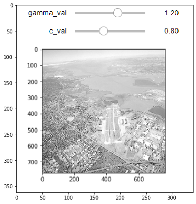

```python
from ipywidgets import interact

def gamma_slider(gamma_val, c_val):
    args = {"gamma_val": gamma_val, "c_val": c_val}
    transformed_img = power_law(task2_img, args)
    plt.imshow(transformed_img, cmap="gray")

# gamma value & scaling factor sliders
interact(gamma_slider, gamma_val=(0.0, 2.0), c_val=(0.0, 2.0));

# ignore below lines
# for lab submission, load and show the slider output screenshot; because slider won't appear in HTML version of notebook
plt.figure(figsize = (7,7))
screenshot_1 = cv2.imread("screenshot_1.PNG")
plt.imshow(screenshot_1)
plt.show()
```

##### Using Transformation Table

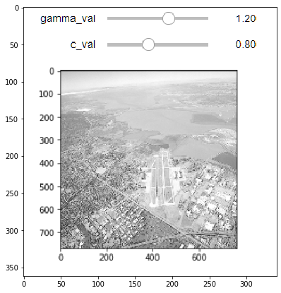

```python
from ipywidgets import interact

def gamma_slider(gamma_val, c_val):
    args = {"gamma_val": gamma_val, "c_val": c_val}
    args["power_law_table"] = gen_power_law_table(args)
    transformed_img = power_law_using_table(task2_img, args)
    plt.imshow(transformed_img, cmap="gray")

# gamma value & scaling factor sliders
interact(gamma_slider, gamma_val=(0.0, 2.0), c_val=(0.0, 2.0));


# ignore below lines
# for lab submission, load and show the slider output screenshot; because slider won't appear in HTML version of notebook
plt.figure(figsize = (7,7))
screenshot_2 = cv2.imread("screenshot_2.PNG")
plt.imshow(screenshot_1)
plt.show()
```

#### Without using Transformation Table

```
aerial.tif
************
Original Image:
```

```
Transformed Image:
```

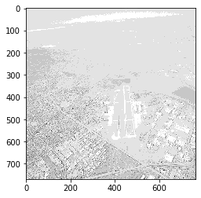

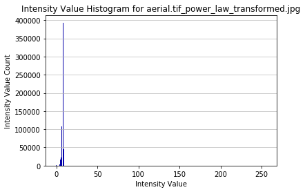

```python
transform_and_hists(task2_img_name, task2_img, power_law, task2_dir, gamma_val=0.4, c_val=1)
```

##### Using Transformation Table

```
aerial.tif
************
Original Image:
```

```
Transformed Image:
```

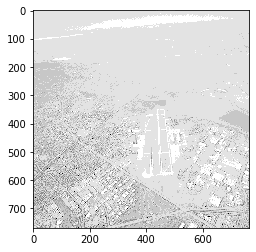

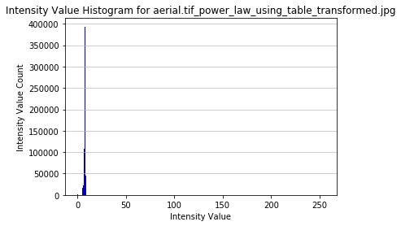

```python
args = {"gamma_val": 0.4, "c_val":1}
power_law_table = gen_power_law_table(args)
transform_and_hists(task2_img_name, task2_img, power_law_using_table, task2_dir, gamma_val=0.4, c_val=1, power_law_table=power_law_table)
```

### Task 3

Read “messi5.jpg” image and apply following transformations using cv2.warpaffine() function:

- Translation
- Rotation
- Sheering in x
- Sheering in y
- Random affine transform

Summarize your findings by providing a figure which contains images before and after geometric transformation.

```python
# open files
task3_img_name = "messi5.jpg"
task3_img = gray_imgs[task3_img_name]
plt.imshow(task3_img, cmap="gray")
plt.show()
```

#### Translation

[figure not shown]

```python
trans_x = 100
trans_y = 100

task3_img_rows, task3_img_cols =task3_img.shape
img3_trans_shape = (task3_img_cols+100, task3_img_rows+100)

trans_M = np.float32([[1,0,trans_x],[0,1,trans_y]])

# enlarged image to contain the translated image
task3_img_translated = np.zeros((task3_img.shape[0]+100, task3_img.shape[1]+100))
# paste the image into the container image
task3_img_translated[:task3_img.shape[0],:task3_img.shape[1]] = task3_img
plt.imshow(task3_img_translated, cmap="gray")
plt.show()
# transform and show
translated_img = cv2.warpAffine(task3_img, trans_M, img3_trans_shape)
plt.imshow(translated_img, cmap="gray")
plt.show()
```

#### Rotation

[figure not shown]

```python
rot_angle = 90
rotation_M = cv2.getRotationMatrix2D((img3_trans_shape[0]/2,img3_trans_shape[1]/2),rot_angle,1)

# enlarged image to contain the translated image
task3_img_rotated = np.zeros((task3_img.shape[0]+100, task3_img.shape[1]+100))
# paste the image into the container image
task3_img_rotated[:task3_img.shape[0],:task3_img.shape[1]] = task3_img
plt.imshow(task3_img_rotated, cmap="gray")
plt.show()
# transform and show
rotated_img = cv2.warpAffine(task3_img_rotated, rotation_M, img3_trans_shape)
plt.imshow(rotated_img, cmap="gray")
plt.show()
```

#### Sheering in X

[figure not shown]

```python
shear_x = .1
shear_x_M = np.float32([[1,shear_x,0],[0,1,0]])

# enlarged image to contain the translated image
task3_img_shear_x = np.zeros((task3_img.shape[0]+100, task3_img.shape[1]+100))
# paste the image into the container image
task3_img_shear_x[:task3_img.shape[0],:task3_img.shape[1]] = task3_img
plt.imshow(task3_img_shear_x, cmap="gray")
plt.show()
# transform and show
shear_x_img = cv2.warpAffine(task3_img_shear_x, shear_x_M, img3_trans_shape)
plt.imshow(shear_x_img, cmap="gray")
plt.show()
```

#### Sheering in Y

[figure not shown]

```python
shear_y = .1
shear_y_M = np.float32([[1,0,0],[shear_y,1,0]])

# enlarged image to contain the translated image
task3_img_shear_y = np.zeros((task3_img.shape[0]+100, task3_img.shape[1]+100))
# paste the image into the container image
task3_img_shear_y[:task3_img.shape[0],:task3_img.shape[1]] = task3_img
plt.imshow(task3_img_shear_y, cmap="gray")
plt.show()
# transform and show
shear_y_img = cv2.warpAffine(task3_img_shear_y, shear_y_M, img3_trans_shape)
plt.imshow(shear_y_img, cmap="gray")
plt.show()
```

#### Random Affine Transformation

[figure not shown]

```python
pts1 = np.float32([[50,50],[200,50],[50,200]])
pts2 = np.float32([[10,100],[200,50],[100,250]])

# enlarged image to contain the translated image
task3_img_random = np.zeros((task3_img.shape[0]+100, task3_img.shape[1]+100))
# paste the image into the container image
task3_img_random[:task3_img.shape[0],:task3_img.shape[1]] = task3_img
plt.imshow(task3_img_random, cmap="gray")
plt.show()

# transform and show
random_M = cv2.getAffineTransform(pts1,pts2)
random_trans_img = cv2.warpAffine(task3_img_random,random_M,img3_trans_shape)
plt.imshow(random_trans_img, cmap="gray")
plt.show()
```

### Task 4

You may have noticed that in task 2 when using interact with some real-time processing, the system takes some time to process.

- This is usually caused by applying exponential mathematical operation withing nested for loops.
- You can use the concept of mapping to apply the transformation function in an efficient manner!
- Try out both techniques (i.e. power-law in nested for loops and mapping) by increasing the size of input image and calculate the time take by each.
- Conclude your findings in the form of graph in which x-axis should indicate the increasing size of image and y-axis should indicate time taken for processing.

#### Trying Power Law Transformation with & without Transformation Table for Processing Time Comparison

```
Original Dimensions :  (280, 450)
Resized Dimensions :  (2800, 4500)
```

[figure not shown]

```python
# upscale the task 3 image for task 4
print('Original Dimensions : ', task3_img.shape)

# increase size to 2X
scale_percent = 1000 # percent of original size
task4_img_width = int(task3_img.shape[1] * scale_percent / 100)
task4_img_height = int(task3_img.shape[0] * scale_percent / 100)
task4_img_dim = (task4_img_width, task4_img_height)

task4_img = cv2.resize(task3_img, task4_img_dim, interpolation = cv2.INTER_AREA)
print('Resized Dimensions : ', task4_img.shape)

plt.imshow(task4_img, cmap="gray")
plt.show()
```

```python
import time
```

```python
start_time = time.time()

args = {"gamma_val": 0.4, "c_val":1}
power_law_table = gen_power_law_table(args)
args["power_law_table"] = power_law_table
task4_img_with_table = power_law_using_table(task4_img, args)

print("--- %s seconds ---" % (time.time() - start_time))
```

```
--- 22.326305627822876 seconds ---
```

[figure not shown]

```python
plt.imshow(task4_img_with_table, cmap="gray")
plt.show()
```

```python
start_time = time.time()

args = {"gamma_val": 0.4, "c_val":1}
task4_img_without_table = power_law(task4_img, args)

print("--- %s seconds ---" % (time.time() - start_time))
```

```
--- 8.010576725006104 seconds ---
```

[figure not shown]

```python
plt.imshow(task4_img_without_table, cmap="gray")
plt.show()
```